IE 582 Homework 1

```r
setwd("C:/Users/user/Desktop/all_ticks_wide.csv")
```

```r
dataw<-read.csv("all_ticks_wide.csv")
```

4.1. Descriptive Analysis

```r
summary(dataw)
```

```
                timestamp         AEFES             AKBNK
 2012-09-17T06:45:00Z:    1   Min.   : 0.0001   Min.   :0.0001
 2012-09-17T07:00:00Z:    1   1st Qu.:19.1605   1st Qu.:5.8500
 2012-09-17T07:15:00Z:    1   Median :20.6465   Median :6.3057
 2012-09-17T07:30:00Z:    1   Mean   :20.9822   Mean   :6.4731
 2012-09-17T07:45:00Z:    1   3rd Qu.:22.7320   3rd Qu.:6.9325
 2012-09-17T08:00:00Z:    1   Max.   :28.5090   Max.   :9.2124
 (Other)             :50006   NA's   :1881      NA's   :803
      AKSA             AKSEN           ALARK            ALBRK
 Min.   : 0.0001   Min.   :0.000   Min.   :0.0001   Min.   :1.026
 1st Qu.: 5.2088   1st Qu.:2.670   1st Qu.:1.5689   1st Qu.:1.225
 Median : 6.9853   Median :2.930   Median :1.9376   Median :1.360
 Mean   : 7.1275   Mean   :3.183   Mean   :2.0609   Mean   :1.365
 3rd Qu.: 8.7200   3rd Qu.:3.750   3rd Qu.:2.4214   3rd Qu.:1.500
 Max.   :15.1189   Max.   :5.190   Max.   :3.5143   Max.   :2.190
 NA's   :1418      NA's   :1841    NA's   :1677     NA's   :3150
     ANACM            ARCLK             ASELS             ASUZU
 Min.   :0.0001   Min.   : 0.0001   Min.   : 0.0001   Min.   : 0.0001
 1st Qu.:1.0470   1st Qu.:11.7111   1st Qu.: 4.9403   1st Qu.: 5.0748
 Median :1.2597   Median :15.0100   Median : 9.2757   Median : 5.9496
 Mean   :1.6721   Mean   :15.3881   Mean   :13.4325   Mean   : 6.4670
 3rd Qu.:2.4021   3rd Qu.:19.0877   3rd Qu.:22.7567   3rd Qu.: 7.1200
 Max.   :3.5021   Max.   :26.4278   Max.   :46.7616   Max.   :15.2800
 NA's   :1847     NA's   :967       NA's   :1209      NA's   :1579
     AYGAZ             BAGFS             BANVT            BRISA
 Min.   : 0.0001   Min.   : 0.0001   Min.   : 0.000   Min.   : 0.0001
 1st Qu.: 5.9515   1st Qu.: 8.2617   1st Qu.: 2.590   1st Qu.: 5.8900
 Median : 7.7238   Median :10.6100   Median : 3.710   Median : 6.7300
 Mean   : 8.1019   Mean   :10.4071   Mean   : 7.628   Mean   : 6.5449
 3rd Qu.:10.2690   3rd Qu.:12.3500   3rd Qu.:11.930   3rd Qu.: 7.3300
 Max.   :13.5935   Max.   :38.4352   Max.   :28.680   Max.   :10.3275
 NA's   :1893      NA's   :1362      NA's   :2061     NA's   :1075
     CCOLA             CEMAS           ECILC            EREGL
 Min.   : 0.0001   Min.   :0.000   Min.   :0.0001   Min.   : 0.0001
 1st Qu.:31.9782   1st Qu.:0.700   1st Qu.:1.1723   1st Qu.: 2.1812
 Median :34.8215   Median :0.870   Median :1.8214   Median : 3.0360
 Mean   :36.8907   Mean   :1.209   Mean   :2.0759   Mean   : 4.1795
 3rd Qu.:42.0497   3rd Qu.:1.500   3rd Qu.:2.7809   3rd Qu.: 6.7587
 Max.   :54.2208   Max.   :7.010   Max.   :4.2278   Max.   :10.4710
 NA's   :1263      NA's   :3618    NA's   :1520     NA's   :839
```

[output cut: 73 more lines]

```
 Min.   :0.0001   Min.   : 0.000   Min.   : 0.000   Min.   :0.0001
 1st Qu.:4.0322   1st Qu.: 4.020   1st Qu.: 0.389   1st Qu.:2.2682
 Median :4.4742   Median : 6.320   Median : 0.966   Median :2.6093
 Mean   :4.7354   Mean   : 5.943   Mean   : 2.434   Mean   :2.5663
 3rd Qu.:5.2460   3rd Qu.: 7.450   3rd Qu.: 4.230   3rd Qu.:2.8740
 Max.   :7.5814   Max.   :14.540   Max.   :10.675   Max.   :3.9581
 NA's   :800      NA's   :1231     NA's   :3957     NA's   :787
     YUNSA           ZOREN
 Min.   :0.000   Min.   :0.0001
 1st Qu.:3.007   1st Qu.:1.0338
 Median :4.108   Median :1.2500
 Mean   :4.080   Mean   :1.2481
 3rd Qu.:4.721   3rd Qu.:1.4265
 Max.   :9.527   Max.   :2.4430
 NA's   :4484    NA's   :1205
```

```r
library(ggplot2)
```

```r
library(zoo)
library(quantmod)
```

```r
dataw$timestamp <- as.POSIXct(dataw$timestamp, format="%Y-%m-%dT%H:%M:%SZ")
```

```r
dataw.xts <- xts(dataw[,2:61], order.by = dataw$timestamp)
```

```r
plot(dataw.xts)
```

[output not shown]

```
plot without title
```

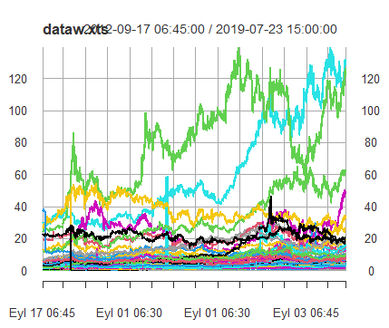

```r
chartSeries(dataw)
```

```
Error in try.xts(x, error = "chartSeries requires an xtsible object"): chartSeries requires an xtsible object
Traceback:

1. chartSeries(dataw)
2. try.xts(x, error = "chartSeries requires an xtsible object")
3. stop(error)
```

[figure not shown]

```r
library(imputeTS)
dataw.xts.imputed <- na_interpolation(dataw.xts, option = "linear")
dataw.xts.imputed.scaled<-scale(dataw.xts.imputed)
```

[output not shown]

I also scaled the given data but it does not change the results. So, I did not use the scaled data for analyses.

```r
cor(dataw.xts.imputed)
```

[output not shown]

[output not shown]

4.2. Moving Window Correlation

```r
monthly_stock_prices <- to.period(dataw.xts.imputed, period = "months", OHLC = FALSE)
```

[output not shown]

```r
correlation_matrix <- cor(monthly_stock_prices$AKBNK, monthly_stock_prices$GARAN)
```

[output not shown]

```r
mo.st.pr.zoo<-zoo(monthly_stock_prices[,c("AKBNK","GARAN")])
```

```r
rolling_correlation <- rollapply(mo.st.pr.zoo, width = 3, FUN = function(x) cor(x[,1], x[,2]), by.column = FALSE, align = "right") # 3 months moving correlation
rolling_correlation
```

2012-11-30 15:30:00 2012-12-31 15:30:00 2013-01-31 15:30:00 2013-02-28 15:30:00 2013-03-29 15:30:00 0.9958936 0.8433188 0.7112467 0.1891022 0.9998830 2013-04-30 14:30:00 2013-05-31 08:45:00 2013-06-28 14:30:00 2013-07-31 14:30:00 2013-08-29 14:30:00 0.9751249 0.8365369 0.9531202 0.9921672 0.9683357 2013-09-30 14:30:00 2013-10-31 15:30:00 2013-11-29 15:30:00 2013-12-31 15:30:00 2014-01-31 15:30:00 0.9116045 0.9519541 0.7074036 0.9999953 0.9994456 2014-02-28 15:30:00 2014-03-28 15:30:00 2014-04-30 14:30:00 2014-05-30 14:30:00 2014-06-30 14:30:00 0.9919243 0.9962264 0.9925877 0.9935613 0.9825999 2014-07-31 14:30:00 2014-08-29 14:30:00 2014-09-30 14:30:00 2014-10-31 15:30:00 2014-11-28 15:30:00 0.9973753 0.9467731 0.9784057 0.8497011 0.9999869 2014-12-31 15:30:00 2015-01-30 15:30:00 2015-02-27 15:30:00 2015-03-31 14:30:00 2015-04-30 14:30:00 0.9996802 0.7332652 0.9477909 0.9928239 0.9949615 2015-05-29 14:30:00 2015-06-30 14:30:00 2015-07-31 14:30:00 2015-08-31 14:30:00 2015-09-30 14:30:00 0.2558374 0.1736983 0.9985549 0.9790838 0.9714125 2015-10-30 14:30:00 2015-11-30 15:30:00 2015-12-31 15:30:00 2016-01-29 15:30:00 2016-02-29 15:30:00 0.8005170 0.9343708 0.9851352 0.9798031 0.8762398 2016-03-31 14:30:00 2016-04-29 14:30:00 2016-05-31 14:30:00 2016-06-30 14:30:00 2016-07-29 14:30:00 0.9650865 0.9977956 0.8905631 0.9184928 0.9044462 2016-08-31 14:30:00 2016-09-30 14:30:00 2016-10-31 14:30:00 2016-11-30 15:00:00 2016-12-30 15:00:00 0.5521157 0.9888291 0.9959072 0.9947156 0.9959958 2017-01-31 15:00:00 2017-02-28 15:00:00 2017-03-31 15:00:00 2017-04-28 15:00:00 2017-05-31 15:00:00 0.9999956 0.9993230 0.9588363 0.9923141 0.9999608 2017-06-30 15:00:00 2017-07-31 15:00:00 2017-08-31 09:30:00 2017-09-29 15:00:00 2017-10-31 15:00:00 0.9998536 0.9955924 0.9314171 0.9604891 0.9978906 2017-11-30 15:00:00 2017-12-29 15:00:00 2018-01-31 15:00:00 2018-02-28 15:00:00 2018-03-30 15:00:00 0.9447771 0.9206925 0.9993508 0.9955372 0.9920221 2018-04-30 15:00:00 2018-05-31 15:00:00 2018-06-29 15:00:00 2018-07-31 15:00:00 2018-08-31 15:00:00 0.9999982 0.9952110 0.9940033 0.9247291 0.9228240 2018-09-28 15:00:00 2018-10-31 15:00:00 2018-11-30 15:00:00 2018-12-31 15:00:00 2019-01-31 15:00:00 0.8560206 0.9875554 0.9540993 0.8348198 0.9452098 2019-02-28 15:00:00 2019-03-29 15:00:00 2019-04-30 15:00:00 2019-05-31 15:00:00 2019-06-28 15:00:00 0.9988387 0.9962676 0.9990952 0.9801084 0.9993823 2019-07-23 15:00:00 0.9872653

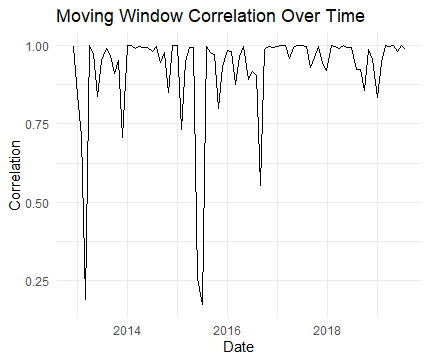

```r
correlation_data <- data.frame(
  Date = index(rolling_correlation),
  Correlation = coredata(rolling_correlation)  )
ggplot(correlation_data, aes(x = Date, y = Correlation)) +
  geom_line() +
  labs(title = "Moving Window Correlation Over Time", x = "Date", y = "Correlation") +
  theme_minimal()
```

```r
stock_matrix <- as.matrix(dataw.xts.imputed)
library(FactoMineR)
```

```r
pca_result <- PCA(stock_matrix, graph = FALSE)
```

```r
summary(pca_result)
```

Call: PCA(X = stock_matrix, graph = FALSE)

Eigenvalues Dim.1 Dim.2 Dim.3 Dim.4 Dim.5 Dim.6 Dim.7 Dim.8 Dim.9 Dim.10 Variance 30.483 10.330 6.420 3.159 2.265 1.338 0.889 0.633 0.528 0.475 % of var. 50.806 17.216 10.700 5.265 3.775 2.230 1.482 1.054 0.880 0.792 Cumulative % of var. 50.806 68.022 78.722 83.987 87.762 89.992 91.473 92.528 93.407 94.199 Dim.11 Dim.12 Dim.13 Dim.14 Dim.15 Dim.16 Dim.17 Dim.18 Dim.19 Dim.20 Variance 0.468 0.354 0.319 0.288 0.246 0.185 0.171 0.144 0.136 0.111 % of var. 0.781 0.591 0.531 0.480 0.410 0.309 0.286 0.240 0.227 0.185 Cumulative % of var. 94.980 95.570 96.101 96.582 96.991 97.300 97.586 97.826 98.053 98.238 Dim.21 Dim.22 Dim.23 Dim.24 Dim.25 Dim.26 Dim.27 Dim.28 Dim.29 Dim.30 Variance 0.098 0.084 0.074 0.069 0.064 0.057 0.056 0.050 0.046 0.043 % of var. 0.163 0.140 0.123 0.115 0.106 0.096 0.093 0.083 0.076 0.071 Cumulative % of var. 98.401 98.541 98.664 98.779 98.885 98.980 99.073 99.156 99.232 99.303 Dim.31 Dim.32 Dim.33 Dim.34 Dim.35 Dim.36 Dim.37 Dim.38 Dim.39 Dim.40 Variance 0.038 0.037 0.033 0.029 0.029 0.025 0.022 0.020 0.018 0.017 % of var. 0.064 0.062 0.055 0.049 0.048 0.041 0.037 0.033 0.030 0.028 Cumulative % of var. 99.367 99.430 99.484 99.533 99.581 99.622 99.659 99.692 99.722 99.750 Dim.41 Dim.42 Dim.43 Dim.44 Dim.45 Dim.46 Dim.47 Dim.48 Dim.49 Dim.50 Variance 0.015 0.014 0.013 0.011 0.011 0.011 0.010 0.008 0.008 0.007 % of var. 0.024 0.023 0.022 0.019 0.018 0.018 0.016 0.014 0.013 0.012 Cumulative % of var. 99.774 99.798 99.819 99.838 99.857 99.874 99.890 99.904 99.917 99.929 Dim.51 Dim.52 Dim.53 Dim.54 Dim.55 Dim.56 Dim.57 Dim.58 Dim.59 Dim.60 Variance 0.006 0.006 0.005 0.005 0.004 0.004 0.004 0.003 0.003 0.002 % of var. 0.010 0.010 0.009 0.008 0.007 0.007 0.006 0.005 0.004 0.004 Cumulative % of var. 99.939 99.949 99.958 99.966 99.973 99.980 99.986 99.992 99.996 100.000

Individuals (the 10 first) Dist Dim.1 ctr cos2 Dim.2 ctr cos2 Dim.3 ctr cos2  
2012-09-17 06:45:00 | 12.484 | -8.394 0.005 0.452 | -0.871 0.000 0.005 | 0.689 0.000 0.003 | 2012-09-17 07:00:00 | 12.473 | -8.415 0.005 0.455 | -0.953 0.000 0.006 | 0.675 0.000 0.003 | 2012-09-17 07:15:00 | 12.471 | -8.408 0.005 0.455 | -0.949 0.000 0.006 | 0.679 0.000 0.003 | 2012-09-17 07:30:00 | 12.477 | -8.403 0.005 0.454 | -0.940 0.000 0.006 | 0.663 0.000 0.003 | 2012-09-17 07:45:00 | 12.488 | -8.401 0.005 0.453 | -0.911 0.000 0.005 | 0.691 0.000 0.003 | 2012-09-17 08:00:00 | 12.465 | -8.393 0.005 0.453 | -0.903 0.000 0.005 | 0.677 0.000 0.003 | 2012-09-17 08:15:00 | 12.453 | -8.396 0.005 0.455 | -0.926 0.000 0.006 | 0.677 0.000 0.003 | 2012-09-17 08:30:00 | 12.440 | -8.386 0.005 0.454 | -0.957 0.000 0.006 | 0.672 0.000 0.003 | 2012-09-17 08:45:00 | 12.435 | -8.384 0.005 0.455 | -0.939 0.000 0.006 | 0.678 0.000 0.003 | 2012-09-17 09:00:00 | 12.442 | -8.385 0.005 0.454 | -0.915 0.000 0.005 | 0.689 0.000 0.003 |

Variables (the 10 first) Dim.1 ctr cos2 Dim.2 ctr cos2 Dim.3 ctr cos2  
AEFES | 0.044 0.006 0.002 | 0.525 2.671 0.276 | 0.674 7.085 0.455 | AKBNK | 0.606 1.205 0.367 | 0.694 4.662 0.482 | -0.187 0.545 0.035 | AKSA | 0.885 2.568 0.783 | 0.119 0.138 0.014 | -0.183 0.521 0.033 | AKSEN | 0.354 0.411 0.125 | 0.520 2.614 0.270 | 0.381 2.266 0.145 | ALARK | 0.751 1.851 0.564 | 0.277 0.745 0.077 | 0.267 1.110 0.071 | ALBRK | 0.031 0.003 0.001 | 0.365 1.292 0.133 | 0.541 4.559 0.293 | ANACM | 0.925 2.805 0.855 | -0.171 0.282 0.029 | 0.227 0.800 0.051 | ARCLK | 0.673 1.488 0.454 | 0.121 0.142 0.015 | -0.638 6.349 0.408 | ASELS | 0.961 3.028 0.923 | 0.008 0.001 0.000 | -0.010 0.001 0.000 | ASUZU | 0.821 2.211 0.674 | 0.302 0.882 0.091 | 0.332 1.713 0.110 |

First 7 principal components can represent 91 % of the data. Moreover, first 4 principal components can represent 83 % of the data.

```r
pca_result$var
```

$coord Dim.1 Dim.2 Dim.3 Dim.4 Dim.5 AEFES 0.04414864 0.525306597 0.674443464 0.022088452 -0.027404027 AKBNK 0.60612745 0.693958841 -0.187037052 -0.157722285 0.172158899 AKSA 0.88481368 0.119270603 -0.182847830 0.144291985 -0.098473109 AKSEN 0.35386221 0.519667991 0.381432044 -0.430934015 -0.334015588 ALARK 0.75114391 0.277401427 0.267003220 -0.225939261 0.374590747 ALBRK 0.03145532 0.365362731 0.540985888 0.423687005 0.129900062 ANACM 0.92464329 -0.170746805 0.226576879 -0.160296103 0.021934231 ARCLK 0.67345738 0.121042314 -0.638428429 -0.029992755 0.209541347 ASELS 0.96078838 0.008062795 -0.009638203 -0.164059153 -0.081362241 ASUZU 0.82104272 0.301891578 0.331619147 0.144934517 -0.165818778 AYGAZ 0.92313664 0.114114151 -0.240831938 -0.100768935 -0.005249170 BAGFS -0.42732844 0.417763702 -0.339695165 0.054058627 -0.282515213 BANVT 0.89854795 0.158609125 0.063070046 -0.264423283 0.037729641 BRISA 0.34181548 0.197603447 -0.505012614 0.679862876 -0.198823871 CCOLA -0.52412812 0.476998298 0.354467602 0.320309831 0.250661448 CEMAS 0.64969563 0.171540975 0.194588350 -0.356611651 -0.425071703 ECILC 0.92128646 0.138513165 -0.203002798 -0.186524696 -0.055339537 EREGL 0.96309343 -0.177351397 0.075687768 0.008218534 -0.099611332 FROTO 0.95664724 -0.202099495 0.080496583 0.053836963 -0.043153365 GARAN 0.72402320 0.581432657 -0.033171944 0.002470849 0.215338578 GOODY 0.55865960 0.201508010 -0.449865544 0.077153517 -0.174163796 GUBRF -0.15785589 0.359631992 -0.654681329 0.460366229 -0.284407460 HALKB -0.59787097 0.691941921 0.209630822 -0.089023434 0.132121086 ICBCT 0.80733661 -0.150694261 0.197910271 -0.014505068 -0.170123697 ISCTR 0.66491652 0.637213142 -0.059331499 -0.050958116 0.269918154 ISDMR 0.79272259 -0.384081653 0.391196133 0.036768238 -0.042366818 ISFIN 0.64435645 -0.486492862 0.152198029 0.122998437 0.336211743 ISYAT 0.83366879 -0.350402190 -0.090226492 0.202948946 0.293499321 KAREL 0.93470215 0.006012605 0.198651714 -0.109773139 0.094454828 KARSN 0.64165307 0.340790970 0.087936571 0.454153610 -0.284825879 KCHOL 0.92733642 -0.021976729 -0.287893355 0.038581885 0.132902391 KRDMB 0.24959076 0.216983279 0.708593947 0.286936498 0.009289938 KRDMD 0.81131797 -0.041211243 0.360953875 0.136296594 -0.336074028 MGROS 0.20225307 0.916295816 -0.076564918 -0.148496036 -0.054254234 OTKAR 0.68324696 0.054618662 -0.615228733 0.100363648 0.209415047 PARSN 0.85419515 -0.241630609 -0.033837220 -0.077829620 -0.252107959 PETKM 0.96732537 -0.009794230 -0.107841963 -0.119021076 -0.017798675 PGSUS 0.31550976 0.104620102 0.657945527 0.355849672 0.323987778 PRKME 0.07827308 0.617855002 0.517239099 -0.412079098 0.015054902 SAHOL 0.31536973 0.849709021 -0.134364247 -0.003328192 0.221456520 SASA 0.91760744 -0.261133414 0.229203195 -0.071387641 -0.037400398 SISE 0.93144837 -0.284649122 -0.057924325 0.045518205 0.092397505 SKBNK -0.49286522 0.589039415 0.352997211 0.373345524 -0.034242729 SODA 0.86558210 -0.430469375 -0.113615464 0.034276399 0.068897059 TCELL 0.85799809 -0.020640942 0.012340260 0.397907816 0.131420107 THYAO 0.82159161 -0.160542292 0.407073637 0.214931970 -0.180562707 TKFEN 0.83483259 -0.400031648 0.222586342 -0.068350054 0.187283404 TOASO 0.83267304 0.165003330 -0.446569739 -0.064191714 -0.067313253 TRKCM 0.97174293 -0.052961665 0.104568423 0.014298179 -0.074163499 TSKB 0.42581413 0.827314449 -0.214571625 -0.029378127 -0.157260515 TTKOM -0.08187158 0.859120456 -0.277162492 0.206865157 0.076805033 TUKAS 0.65514260 -0.208542972 -0.190789991 0.219773910 0.418135728 TUPRS 0.92465127 -0.290268240 0.020860969 -0.063577961 0.101300928 USAK 0.70188079 0.470677863 -0.210153135 -0.324002171 -0.105720752 VAKBN 0.50530082 0.811335057 -0.052566255 -0.122297977 0.164933341 VESTL 0.86099166 -0.096213574 -0.224121103 0.226516501 0.006381811 YATAS 0.94007807 0.069877744 0.138391553 -0.082692414 -0.014785241 YKBNK -0.22496288 0.888979909 0.144139379 0.030119550 0.176673335 YUNSA 0.49758221 0.008864437 0.662492946 0.339811228 -0.259265147 ZOREN 0.70820672 0.325974816 -0.180952060 0.319142738 -0.267232348

$cos2 Dim.1 Dim.2 Dim.3 Dim.4 Dim.5 AEFES 0.0019491027 2.759470e-01 4.548740e-01 4.878997e-04 7.509807e-04 AKBNK 0.3673904830 4.815789e-01 3.498286e-02 2.487632e-02 2.963869e-02 AKSA 0.7828952515 1.422548e-02 3.343333e-02 2.082018e-02 9.696953e-03 AKSEN 0.1252184662 2.700548e-01 1.454904e-01 1.857041e-01 1.115664e-01 ALARK 0.5642171764 7.695155e-02 7.129072e-02 5.104855e-02 1.403182e-01 ALBRK 0.0009894372 1.334899e-01 2.926657e-01 1.795107e-01 1.687403e-02 ANACM 0.8549652120 2.915447e-02 5.133708e-02 2.569484e-02 4.811105e-04 ARCLK 0.4535448469 1.465124e-02 4.075909e-01 8.995653e-04 4.390758e-02 ASELS 0.9231143026 6.500867e-05 9.289495e-05 2.691541e-02 6.619814e-03 ASUZU 0.6741111522 9.113852e-02 1.099713e-01 2.100601e-02 2.749587e-02 AYGAZ 0.8521812513 1.302204e-02 5.800002e-02 1.015438e-02 2.755378e-05 BAGFS 0.1826095997 1.745265e-01 1.153928e-01 2.922335e-03 7.981485e-02 BANVT 0.8073884264 2.515685e-02 3.977831e-03 6.991967e-02 1.423526e-03 BRISA 0.1168378234 3.904712e-02 2.550377e-01 4.622135e-01 3.953093e-02 CCOLA 0.2747102909 2.275274e-01 1.256473e-01 1.025984e-01 6.283116e-02 CEMAS 0.4221044123 2.942631e-02 3.786463e-02 1.271719e-01 1.806860e-01 ECILC 0.8487687328 1.918590e-02 4.121014e-02 3.479146e-02 3.062464e-03 EREGL 0.9275489566 3.145352e-02 5.728638e-03 6.754430e-05 9.922418e-03 FROTO 0.9151739390 4.084421e-02 6.479700e-03 2.898419e-03 1.862213e-03 GARAN 0.5242095995 3.380639e-01 1.100378e-03 6.105094e-06 4.637070e-02 GOODY 0.3121005519 4.060548e-02 2.023790e-01 5.952665e-03 3.033303e-02 GUBRF 0.0249184810 1.293352e-01 4.286076e-01 2.119371e-01 8.088760e-02 HALKB 0.3574497015 4.787836e-01 4.394508e-02 7.925172e-03 1.745598e-02 ICBCT 0.6517923999 2.270876e-02 3.916848e-02 2.103970e-04 2.894207e-02 ISCTR 0.4421139781 4.060406e-01 3.520227e-03 2.596730e-03 7.285581e-02 ISDMR 0.6284091118 1.475187e-01 1.530344e-01 1.351903e-03 1.794947e-03 ISFIN 0.4151952391 2.366753e-01 2.316424e-02 1.512862e-02 1.130383e-01 ISYAT 0.6950036515 1.227817e-01 8.140820e-03 4.118827e-02 8.614185e-02 KAREL 0.8736681038 3.615142e-05 3.946250e-02 1.205014e-02 8.921715e-03 KARSN 0.4117186684 1.161385e-01 7.732841e-03 2.062555e-01 8.112578e-02 KCHOL 0.8599528430 4.829766e-04 8.288258e-02 1.488562e-03 1.766305e-02 KRDMB 0.0622955496 4.708174e-02 5.021054e-01 8.233255e-02 8.630295e-05 KRDMD 0.6582368505 1.698367e-03 1.302877e-01 1.857676e-02 1.129458e-01 MGROS 0.0409063026 8.395980e-01 5.862187e-03 2.205107e-02 2.943522e-03 OTKAR 0.4668264082 2.983198e-03 3.785064e-01 1.007286e-02 4.385466e-02 PARSN 0.7296493583 5.838535e-02 1.144957e-03 6.057450e-03 6.355842e-02 PETKM 0.9357183650 9.592694e-05 1.162989e-02 1.416602e-02 3.167928e-04 PGSUS 0.0995464089 1.094537e-02 4.328923e-01 1.266290e-01 1.049681e-01 PRKME 0.0061266745 3.817448e-01 2.675363e-01 1.698092e-01 2.266501e-04 SAHOL 0.0994580691 7.220054e-01 1.805375e-02 1.107686e-05 4.904299e-02 SASA 0.8420034221 6.819066e-02 5.253410e-02 5.096195e-03 1.398790e-03 SISE 0.8675960746 8.102512e-02 3.355227e-03 2.071907e-03 8.537299e-03 SKBNK 0.2429161271 3.469674e-01 1.246070e-01 1.393869e-01 1.172564e-03 SODA 0.7492323752 1.853039e-01 1.290847e-02 1.174872e-03 4.746805e-03 TCELL 0.7361607153 4.260485e-04 1.522820e-04 1.583306e-01 1.727124e-02 THYAO 0.6750127783 2.577383e-02 1.657089e-01 4.619575e-02 3.260289e-02 TKFEN 0.6969454582 1.600253e-01 4.954468e-02 4.671730e-03 3.507507e-02 TOASO 0.6933443932 2.722610e-02 1.994245e-01 4.120576e-03 4.531074e-03 TRKCM 0.9442843124 2.804938e-03 1.093455e-02 2.044379e-04 5.500225e-03 TSKB 0.1813176771 6.844492e-01 4.604098e-02 8.630743e-04 2.473087e-02 TTKOM 0.0067029559 7.380880e-01 7.681905e-02 4.279319e-02 5.899013e-03 TUKAS 0.4292118215 4.349017e-02 3.640082e-02 4.830057e-02 1.748375e-01 TUPRS 0.8549799622 8.425565e-02 4.351800e-04 4.042157e-03 1.026188e-02 USAK 0.4926366397 2.215377e-01 4.416434e-02 1.049774e-01 1.117688e-02 VAKBN 0.2553289237 6.582646e-01 2.763211e-03 1.495680e-02 2.720301e-02 VESTL 0.7413066340 9.257052e-03 5.023027e-02 5.130973e-02 4.072751e-05 YATAS 0.8837467808 4.882899e-03 1.915222e-02 6.838035e-03 2.186033e-04 YKBNK 0.0506082972 7.902853e-01 2.077616e-02 9.071873e-04 3.121347e-02 YUNSA 0.2475880544 7.857824e-05 4.388969e-01 1.154717e-01 6.721842e-02 ZOREN 0.5015567559 1.062596e-01 3.274365e-02 1.018521e-01 7.141313e-02

$contrib Dim.1 Dim.2 Dim.3 Dim.4 Dim.5 AEFES 0.006393961 2.6713819882 7.085465897 1.544444e-02 0.033155380 AKBNK 1.205211144 4.6620584100 0.544919825 7.874588e-01 1.308531511 AKSA 2.568259456 0.1377136903 0.520783158 6.590618e-01 0.428115092 AKSEN 0.410774633 2.6143409083 2.266270060 5.878456e+00 4.925595060 ALARK 1.850893968 0.7449509257 1.110478893 1.615940e+00 6.194971676 ALBRK 0.003245813 1.2922863982 4.558785777 5.682402e+00 0.744978859 ANACM 2.804682345 0.2822379812 0.799665742 8.133690e-01 0.021240760 ARCLK 1.487837408 0.1418354265 6.348947657 2.847570e-02 1.938495057 ASELS 3.028242964 0.0006293345 0.001447003 8.520059e-01 0.292261115 ASUZU 2.211397167 0.8822918720 1.712996630 6.649444e-01 1.213927231 AYGAZ 2.795549663 0.1260634795 0.903452811 3.214364e-01 0.001216484 BAGFS 0.599044164 1.6895524975 1.797446788 9.250639e-02 3.523781020 BANVT 2.648608427 0.2435379353 0.061961739 2.213304e+00 0.062847873 BRISA 0.383282239 0.3780065412 3.972663342 1.463135e+01 1.745268643 CCOLA 0.901177138 2.2026421377 1.957178369 3.247747e+00 2.773960813 CEMAS 1.384698203 0.2848695529 0.589808439 4.025620e+00 7.977184255 ECILC 2.784355020 0.1857344194 0.641920667 1.101322e+00 0.135206096 EREGL 3.042790685 0.3044945421 0.089233661 2.138112e-03 0.438069214 FROTO 3.002194889 0.3954037094 0.100932773 9.174931e-02 0.082215666 GARAN 1.719650564 3.2727220696 0.017140329 1.932565e-04 2.047240740 GOODY 1.023834532 0.3930926388 3.152410557 1.884313e-01 1.339186299 GUBRF 0.081744172 1.2520651275 6.676321194 6.708858e+00 3.571142674 HALKB 1.172600771 4.6349981976 0.684522275 2.508710e-01 0.770671867 ICBCT 2.138181310 0.2198384795 0.610118200 6.660107e-03 1.277776383 ISCTR 1.450338858 3.9307889988 0.054833752 8.219936e-02 3.216543459 ISDMR 2.061473282 1.4280960163 2.383781348 4.279444e-02 0.079245923 ISFIN 1.362032912 2.2912012077 0.360823958 4.788956e-01 4.990579633 ISYAT 2.279934252 1.1886223925 0.126807649 1.303813e+00 3.803114801 KAREL 2.866036503 0.0003499739 0.614698202 3.814467e-01 0.393888732 KARSN 1.350628147 1.1243109495 0.120452651 6.529008e+00 3.581658112 KCHOL 2.821044088 0.0046755895 1.291042662 4.712036e-02 0.779813633 KRDMB 0.204358289 0.4557879314 7.821178315 2.606233e+00 0.003810227 KRDMD 2.159322096 0.0164415101 2.029461092 5.880465e-01 4.986492107 MGROS 0.134191641 8.1279624935 0.091313913 6.980257e-01 0.129954856 OTKAR 1.531407088 0.0288796811 5.895905738 3.188560e-01 1.936158913 PARSN 2.393588236 0.5652156543 0.017834735 1.917483e-01 2.806069010 PETKM 3.069590133 0.0009286474 0.181156067 4.484246e-01 0.013986227 PGSUS 0.326558381 0.1059596618 6.743062557 4.008435e+00 4.634282346 PRKME 0.020098333 3.6955868862 4.167350274 5.375302e+00 0.010006474 SAHOL 0.326268586 6.9895745541 0.281219064 3.506375e-04 2.165220722 SASA 2.762161664 0.6601386765 0.818311486 1.613198e-01 0.061755789 SISE 2.846117432 0.7843862681 0.052263595 6.558612e-02 0.376916994 SKBNK 0.796877538 3.3589148680 1.940974632 4.412285e+00 0.051768068 SODA 2.457829612 1.7938858422 0.201072281 3.719050e-02 0.209568787 TCELL 2.414948506 0.0041244809 0.002372061 5.011949e+00 0.762515831 THYAO 2.214354918 0.2495107167 2.581209565 1.462324e+00 1.439399505 TKFEN 2.286304279 1.5491696704 0.771745910 1.478834e-01 1.548544968 TOASO 2.274491116 0.2635698330 3.106389381 1.304366e-01 0.200044400 TRKCM 3.097690412 0.0271539836 0.170325011 6.471473e-03 0.242831854 TSKB 0.594806059 6.6260010825 0.717169635 2.732058e-02 1.091854137 TTKOM 0.021988804 7.1452660386 1.196592359 1.354617e+00 0.260438147 TUKAS 1.408013802 0.4210187135 0.567007084 1.528952e+00 7.718977765 TUPRS 2.804730733 0.8156602969 0.006778698 1.279543e-01 0.453056201 USAK 1.616076615 2.1446569312 0.687937616 3.323055e+00 0.493452922 VAKBN 0.837597266 6.3725135527 0.043041895 4.734567e-01 1.200997628 VESTL 2.431829506 0.0896154680 0.782425170 1.624207e+00 0.001798097 YATAS 2.899099237 0.0472702649 0.298329690 2.164577e-01 0.009651216 YKBNK 0.166018682 7.6505767381 0.323625403 2.871697e-02 1.378057214 YUNSA 0.812203626 0.0007606985 6.836594605 3.655250e+00 2.967655686 ZOREN 1.645338733 1.0286754648 0.510040160 3.224123e+00 3.152849848

It is seen that TRKCM, PETKM, EREGL, FROTO, ASELS have higher contribution to first principal component.

```r
plot.PCA(pca_result)
```

[output not shown]

```r
plot.PCA(pca_result)
```

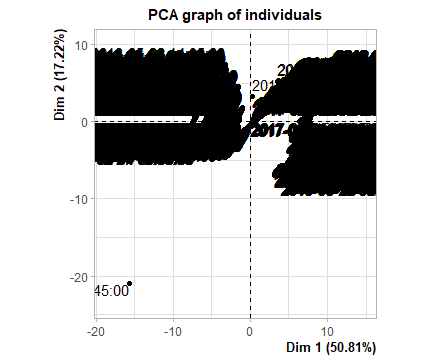

# 4.4. Google Trends

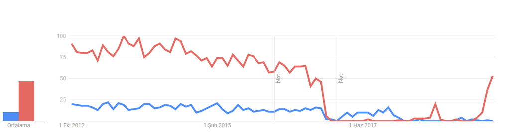

Red line shows IST:GARAN and blue line shows IST:AKBNK search volumes between 17.09.2012 and 23.07.2019. It does not seem to give consistent results with the moving correlation values.